# Applying K-Means Clustering in retail industry

Charan Gullipalli, Lavanya Guntupalli, Arun Pandian (Advisor: Dr. Cohen)

2025-12-09

## Introduction

Retail businesses generate massive amounts of sales and customer data.

To make sense of this data, companies increasingly use clustering methods like K-Means to identify hidden patterns in purchasing behavior and product movement.

Research shows that K-Means helps improve:

- Customer segmentation
- Inventory forecasting
- Marketing targeting
- Demand planning

Studies across retail markets—from large chains to small grocery stores—show that K-Means can separate products into meaningful groups such as fast, moderate, and slow movers.

## Introduction

Improvements like weighted K-Means and MiniBatch K-Means have made clustering faster and more accurate, especially for large datasets.

However, many past studies do not clearly report preprocessing steps or cluster validation.

This project fills those gaps by:

## Problem & Research Questions

**Problem**

- Overstocking slow movers → wasted space and cost
- Understocking fast movers → stock-outs and lost sales

**Research Questions**

Can K-Means find meaningful clusters in the county’s alcohol sales?

Do clusters map to:

- Fast-moving
- Moderate-moving
- Slow-moving items?

How can these clusters help managers make better decisions?

## Literature Review

K-Means is widely used in retail analytics:

- Customer segmentation
- Product grouping
- Demand forecasting

Prasetiya and Prayoga (2025):

- K-Means + association rules helps targeted marketing.
- Works well on large retail datasets.

Omol et al. (2024):

- K-Means for grocery stores in Kenya.
- Customer behavior linked to age and income.

## Literature Review

Bala (2012):

- Clustering + demand forecasting → better inventory accuracy.

Sitorus et al. (2023):

- Products clustered into fast, medium, slow demand categories.

## Literature Review

**Gaps on Many papers:** - Do not clearly show data preprocessing.

- Do not fully explain how K is chosen.
- Use non-public datasets.

**Our contribution** Use an open government dataset.

Clearly document:

- Cleaning and feature engineering
- Choosing K
- Cluster validation and interpretation

## Methods: K-Means Overview

K-Means is an unsupervised machine learning algorithm that groups similar data points into K clusters. Each cluster has a centroid, and items are assigned to the cluster whose centroid they are closest to.

Mathematically, K-Means works by minimizing the Within-Cluster Sum of Squares (WCSS):

$$WCSS = \sum_{k=1}^{K} \sum_{x_i \in C_k} \| x_i - \mu_k \|^2$$

The goal is to create clusters that are compact (low variance) and well separated.

In this project, K-Means is used to group retail items based on their sales behavior—helping identify fast-, moderate-, and slow-moving products.

Why we use it: - Finds natural patterns in sales data

- Helps classify product movement levels
- Supports better inventory planning
- Simplifies complex data into clear groups

**Simple Explanation:** K-Means automatically divides items into groups based on how they sell. This helps managers quickly understand which products sell fast, which are steady, and which move slowly.

## Methods: Choosing K

We used three approaches:

**Elbow Method** (MacQueen 1967)

- Plot WCSS vs. K
- Look for the “elbow” where improvement slows down
  $$WCSS = \sum_{k=1}^{K} \sum_{x_i \in C_k} \| x_i - \mu_k \|^2$$

**Silhouette Coefficient** (Rousseeuw 1987)

Measures how well items fit into their assigned cluster vs neighbors

Range: -1 to 1 (higher is better)
$$s(i) = \frac{b(i) - a(i)}{\max(a(i), b(i))}$$

## Methods: Choosing K

**Calinski–Harabasz Index** Measures how well clusters are formed by comparing:(Caliński and Harabasz (1974))

- Between-cluster variance (how far clusters are from each other)
- Within-cluster variance (how compact each cluster is)

Higher CH values = better, clearer clusters.

**Why It Works for Our Data**

This also fits business logic of Fast, Moderate, and Slow-moving items.

## Data Source

Dataset: Warehouse and Retail Sales

- Montgomery County Open Data Portal (Montgomery County, Maryland, Government 2025)

Period: 2017–2020

Records include:

- Supplier name
- Item code and item type (beer, wine, liquor, etc.)
- Retail sales, retail transfers, warehouse sales
- Year and month

Public-domain dataset → analysis is reproducible

## Data Preprocessing

Aggregated data from monthly level to item level: - One row per supplier–item.

Created:

- TOTAL_SALES = RETAIL_SALES + RETAIL_TRANSFERS + WAREHOUSE_SALES

Removed:

- Duplicates
- Items with TOTAL_SALES = 0

Handled missing values:

- Replaced NAs in sales with 0

Standardized numeric features for clustering:

- TOTAL_SALES, RETAIL_SALES, WAREHOUSE_SALES

## Elbow Method

The Elbow Method evaluates different values of K by computing the Within-Cluster Sum of Squares (WCSS) for each K. As K increases, WCSS decreases because clusters become smaller. The “elbow point” is where the reduction in WCSS slows down, indicating the best balance between simplicity and accuracy.

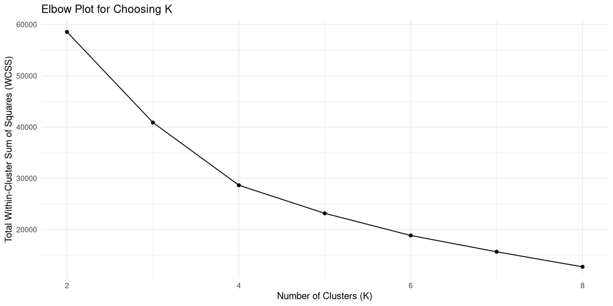

## Silhouette Analysis

```
[1] 0.9712268
```

```
  cluster  size ave.sil.width
1       1    17          0.19
2       2 37667          0.98
3       3   240          0.09
```

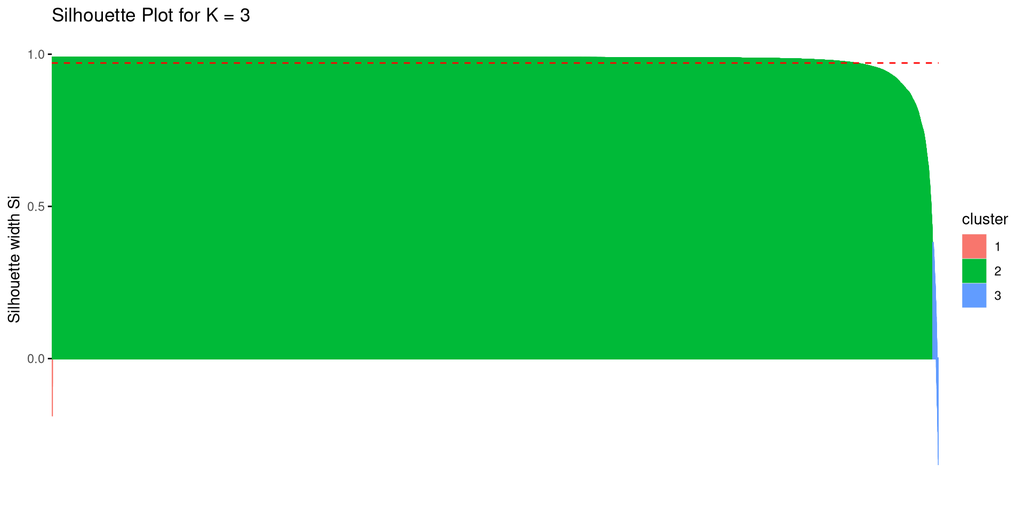

## Cluster Profiling: Sizes

```
# A tibble: 3 × 2
  cluster     n
  <fct>   <int>
1 1          17
2 2       37667
3 3         240
```

Cluster sizes

- Cluster 1: 17 items
- Cluster 2: 37,667 items
- Cluster 3: 240 items

This suggests:

- A small set of very high-volume items (Cluster 1),
- A large pool of low-volume items (Cluster 2),
- A mid-sized group with moderate sales (Cluster 3).

## Cluster Profiling: Means

```
# A tibble: 3 × 4
  TOTAL_SALES RETAIL_SALES WAREHOUSE_SALES cluster
        <dbl>        <dbl>           <dbl> <fct>
1     36.6         24.3            36.2    1
2     -0.0440      -0.0527         -0.0381 2
3      4.32         6.55            3.42   3
```

```
# A tibble: 3 × 5
  cluster mean_total_sales median_total_sales mean_retail_sales mean_wh_sales
  <fct>              <dbl>              <dbl>             <dbl>         <dbl>
1 1                138991.          110963.              9532.       120143.
2 2                   155.               8.98              36.4          82.7
3 3                 16695.           12116.              2615.        11521.
```

**Interpretation**

- Cluster 1 has the highest total sales (≈139,000 on average), making it the Fast-Moving cluster.
- Cluster 2 has very low total sales (≈155), representing Slow-Moving items.
- Cluster 3 shows moderate total sales (≈16,695), identifying it as the Moderate-Moving cluster.

## Cluster Visualization: Scatter Plot

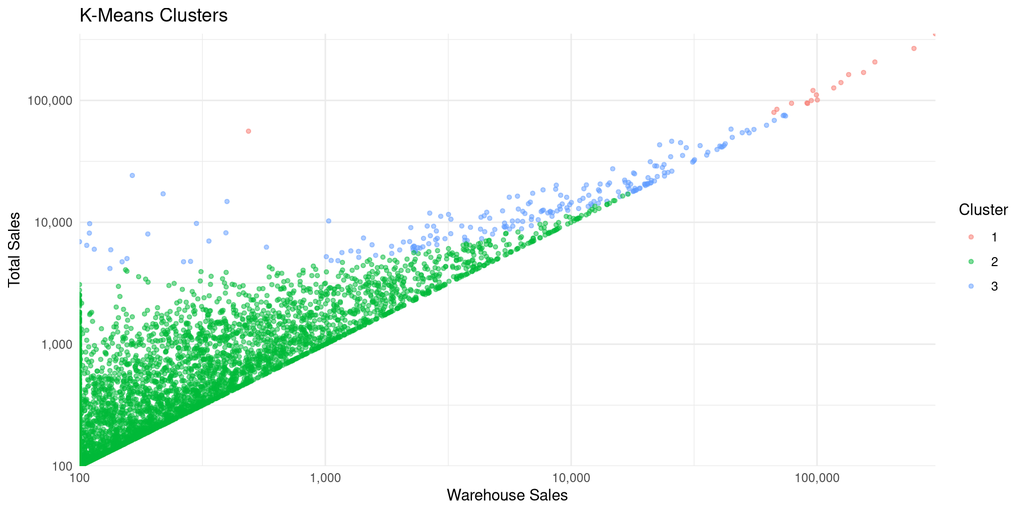

**Interpretation**

- Cluster 1: points in high-sales region → Fast-Moving.
- Cluster 2: dense cloud near origin → Slow-Moving.
- Cluster 3: middle zone → Moderate-Moving.

## Exploratory Analysis:Sales Trend

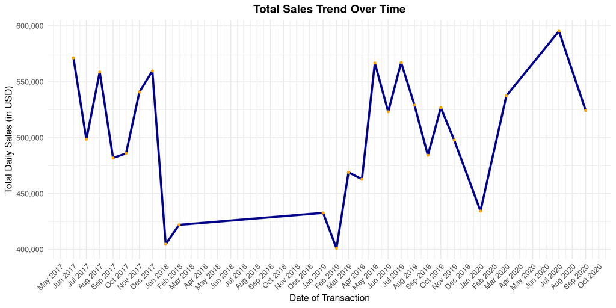

**Key takeaway** Clear seasonal patterns:

- Peaks around mid-year and December.
- Dips in early months.

2020 shows irregularities → likely COVID-19 effect.

## Exploratory Analysis: Top Suppliers

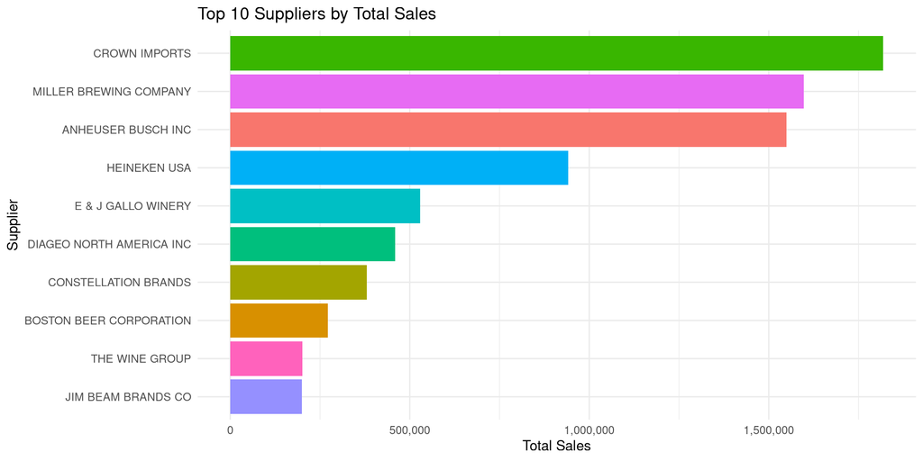

**Key takeaway**

- A few suppliers (e.g., Crown Imports, Miller, Anheuser Busch) dominate sales.
- These suppliers contribute heavily to fast-moving items.

## Exploratory Analysis: Item Types

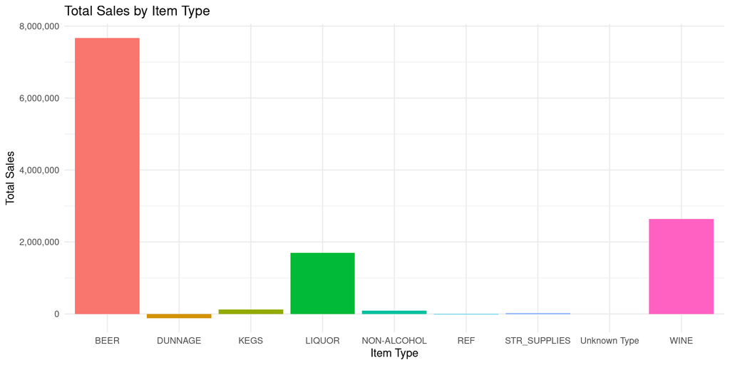

**Key takeaway**

- Beer dominates total sales.
- Liquor and wine are moderate.
- Kegs and non-alcoholic products → slow-moving side.

## Exploratory Analysis:Retail vs Warehouse Sales

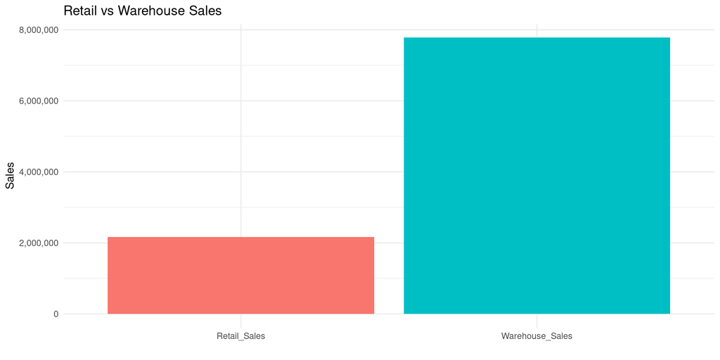

## Exploratory Analysis:Monthly Sales Heatmap

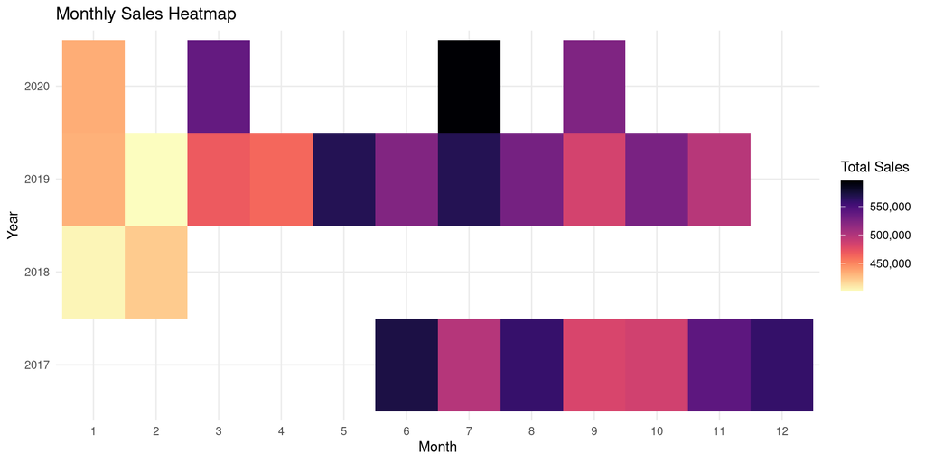

**Key takeaway**

- Sales peak in summer and December due to seasonal and holiday demand, while early months show lower activity. Unusual patterns in 2020 suggest external disruptions like COVID-19. Recognizing these seasonal shifts helps optimize inventory planning.

## Cluster Insights:Fast-Moving(Cluster 1)

Items in this cluster represent the highest-performing products in the entire dataset. Although Cluster 1 contains only a small number of items, these products generate exceptionally high total and warehouse sales, making them the core revenue drivers for the county’s retail system.

These are predominantly major beer brands and leading liquor products, which sell consistently in high volumes across months and seasons. Because of their strong and stable demand, they require close operational attention.

Management actions:

- Ensure frequent replenishment to prevent stock-outs, especially during peak seasons.
- Apply tight demand forecasting, as small forecasting errors can create major revenue losses.
- Allocate priority shelf space and warehouse storage, since these items sustain customer satisfaction and overall sales performance.

## Cluster Insights: Slow-Moving (Cluster 2)

Cluster 2 contains the largest number of items, but each item contributes very little to total sales. These products typically have low, irregular, or seasonal demand, and many belong to niche categories such as specialty beverages, certain kegs, or non-alcoholic items.

Because they occupy significant space but contribute minimally to revenue, these items pose inventory risks, including excess holding costs and potential spoilage or obsolescence.

## Cluster Insights: Slow-Moving (Cluster 2)

**Risks**:

- Overstocking, due to slow turnover
- Increased carrying and storage costs
- Shelf space tied up by low-performing items

**Management actions**:

- Reduce order quantities to avoid unnecessary stock accumulation.
- Use discounts, promotions, or bundling to stimulate movement.
- Consider discontinuing chronic slow movers that repeatedly underperform and do not serve strategic purposes.

## Cluster Insights: Moderate-Moving (Cluster 3)

Items in this cluster fall between fast and slow movers. They exhibit moderate total sales with stable, predictable demand patterns. Many products in this group include wines and mid-tier spirits that customers purchase regularly, though in lower volumes than the top-selling items.

Moderate movers help maintain a balanced product assortment. They diversify revenue streams, support customer preferences, and contribute to consistent monthly sales.

## Cluster Insights: Moderate-Moving (Cluster 3)

**Role & characteristics:**

- Provide assortment breadth to accommodate varied customer tastes
- Generate steady, reliable revenue
- Show consistent demand with fewer extreme peaks or drops

**Management actions:**

- Maintain balanced safety stock—not excessive, but sufficient to avoid shortages
- Conduct regular performance reviews to detect upward or downward trends
- Adjust assortment and marketing strategies based on performance signals

## Conclusion: Key Findings

K-Means clustering with K = 3 successfully segmented retail items into Fast-Moving, Moderate-Moving, and Slow-Moving groups. The analysis showed strong alignment between statistical patterns and real-world retail behavior:

- Cluster 1 captured the high-demand, high-revenue items that drive operational performance
- Cluster 2 contained low-selling items that require cost control and strategic review
- Cluster 3 represented stable, moderate performers that support consistent sales

Seasonal peaks (especially summer and December) and supplier concentration patterns further validated the cluster interpretations. Overall, clustering simplified a large and complex dataset into three clear categories that directly support business decision-making.

## Conclusion: Managerial Implications

This clustering framework provides actionable guidance for retail managers:

- Fast-moving items: Prioritize to prevent stock-outs and protect revenue.
- Moderate-moving items: Maintain stable inventory and monitor for performance changes.
- Slow-moving items: Evaluate carefully to reduce waste, lower holding costs, and free shelf space.

Implementing K-Means clustering as part of inventory analytics helps retailers:

- Strengthen forecasting accuracy
- Improve inventory planning and allocation
- Reduce overstock and lost-sales risks
- Build a data-driven retail strategy grounded in objective performance patterns

Through this approach, retailers can better align supply with actual demand and enhance overall operational efficiency.

## Business Value

Using K-Means clustering on open government sales data:

Helps managers:

- Prioritize fast movers for availability and service level.
- Maintain balanced stocks for moderate movers.
- Control costs and space taken by slow movers.

Supports:

- Better demand forecasting
- More efficient inventory control
- Data-driven promotion and assortment decisions

Overall, clustering turns raw sales data into clear, actionable categories for retail decision-making.

## Limitations

**Cluster Size Imbalance:**One drawback is that Cluster 2 is significantly larger than Clusters 1 and 3. This reflects the fact that most retail items move slowly, but it also indicates that the clustering structure is severely uneven. This could affect how well the smaller high-value clusters are represented.

**K-Means Assumptions:**K-Means assumes spherical, uniformly sized clusters and is sensitive to initial centroid location and outliers. Given the skewed distribution of retail sales data, these assumptions may not always be valid.

**Limited Feature Set:**The analysis only considers sales-related factors (total sales, retail sales, and warehouse sales). Important business parameters, such as profit margin, price elasticity, promotional activity, consumer demographics, and item lifetime, were not considered and could have an impact on cluster formation.

## Future Work

**Test Alternative Clustering Algorithms:**Investigate models that can handle skewed and imbalanced data, such as DBSCAN, Gaussian Mixture Models, and hierarchical clustering, to see if a more balanced segmentation emerges.

**Add more business features:**Use margin, profitability, seasonality indications, promotions, or RFM-style customer KPIs to create clusters that reflect both sales volume and business value.

**Try Weighted or Hybrid models:**Consider weighted K-Means, MiniBatch K-Means, or hybrid models to reduce sensitivity to extreme values and improve resilience.

**Extend to customer-level clustering:**Using the same dataset, cluster consumer behavior (frequency, recency, spend, brand loyalty) to supplement product-level segmentation.

## References

Bala, Pradip Kumar. 2012. “Improving Inventory Performance with Clustering-Based Demand Forecasts.” *Decision Tree-Based Demand Forecasts for Improving Inventory Performance*. https://www.researchgate.net/publication/261023207_Decision_tree_based_demand_forecasts_for_improving_inventory_performance.

Caliński, T., and J. Harabasz. 1974. “A Dendrite Method for Cluster Analysis.” *Communications in Statistics* 3 (1): 1–27. https://doi.org/10.1007/BF02291575.

MacQueen, J. B. 1967. “Some Methods for Classification and Analysis of Multivariate Observations.” In *Proceedings of the Fifth Berkeley Symposium on Mathematical Statistics and Probability, Vol. 1*, 281–97. Berkeley, CA: University of California Press. https://projecteuclid.org/ebooks/berkeley-symposium-on-mathematical-statistics-and-probability/Proceedings-of-the-Fifth-Berkeley-Symposium-on-Mathematical-Statistics-and/chapter/Some-methods-for-classification-and-analysis-of-multivariate-observations/bsmsp/1200512992.

Montgomery County, Maryland, Government. 2025. “Warehouse and Retail Sales.” Montgomery County Data Portal; https://data.montgomerycountymd.gov/Community-Recreation/Warehouse-and-Retail-Sales/v76h-r7br/about_data.

Omol, Edwin, Dorcas Onyangor, Lucy Mburu, and Paul Abuonji. 2024. “Application of k-Means Clustering for Customer Segmentation in Grocery Stores in Kenya.” *International Journal of Science, Technology and Management (IJSTM)*. https://ijstm.inarah.co.id/index.php/ijstm/article/view/1024.

Prasetiya, Yanda Rizky, and Firlan Prayoga. 2025. “Systematic Literature Review: Customer Segmentation in Retail.” *Journal of Technovasia*. https://journal-iam.com/index.php/technovasia/article/view/11.

Rousseeuw, Peter J. 1987. “Silhouettes: A Graphical Aid to the Interpretation and Validation of Cluster Analysis.” *Journal of Computational and Applied Mathematics* 20: 53–65. https://doi.org/10.1016/0377-0427(87)90125-7.

Sitorus, Zulham, Irwan Syahputra, Chairul Indra Angkat, and Dewi Sartika. 2023. “Implementation of k-Means Clustering for Inventory Projection.” *International Journal of All Research in Science, Technology and Computers (IJARSCT)*. https://www.ijarsct.co.in/Paper19084.pdf.